# **Let's play with randomness**

We will simulate:

- A coin toss (count heads)
- Two coins toss (count heads)
- A dice roll
- Two dice roll
- Same sex children
- Sum of uniform distributions

## Tossing a single coin

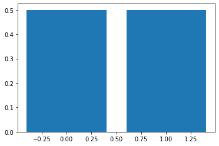

```python
import numpy as np
import matplotlib.pyplot as plt

def bernoulli(prob=0.5):
    # Tossing a single coin
    # prob: probability of success
    if np.random.rand() < prob:
        return 1  # success
    else:
        return 0  # failure

n = 1000000
coin = np.array([0, 0])
for i in range(n):
    coin[bernoulli()] += 1  # increment in 1 according to bern result
coin = coin / n
p = plt.bar(range(2), coin)
```

Let's try with $n\in [1000, 10000, 100000, 1000000]$

## Tossing two coins

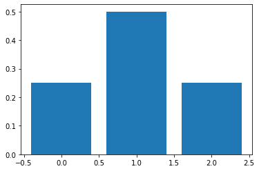

```python
n = 1000000
two_coins = np.array([0, 0, 0])
for i in range(n):
    two_coins[bernoulli() + bernoulli()] += 1
two_coins = two_coins / n
p = plt.bar(range(3), two_coins)
```

Let's try with $n\in [1000, 10000, 100000, 1000000]$

## Let's roll a dice

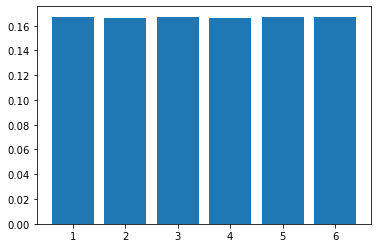

```python
n = 1000000
dice = np.zeros(6)
for i in range(n):
    di = int(np.floor(np.random.rand()*6))
    dice[di] += 1
dice = dice / n
p = plt.bar(range(1,7), dice)
```

Let's try with $n\in [1000, 10000, 100000, 1000000]$

## Two dices

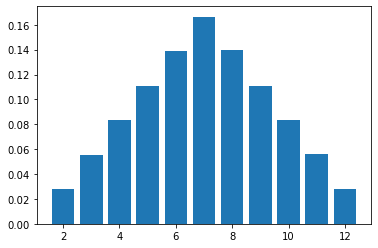

```python
n = 1000000
dice = np.zeros(11)
for i in range(n):
    di1 = int(np.floor(np.random.rand()*6))
    di2 = int(np.floor(np.random.rand()*6))
    dice[di1+di2] += 1
dice = dice / n
p = plt.bar(range(2,13), dice)
```

Let's try with $n\in [1000, 10000, 100000, 1000000]$

## Probability of having three kids of the same sex

**Assignment 1**: How likely is it that a family with three children has all boys or all girls? Let's assume that a child is equally likely to be a boy or a girl. Instead of observing the result of actual births, a toss of a fair coin could be used to simulate a birth. If the toss results in heads (H), then we could say a boy was born; if the toss results in tails (T), then we could say a girl was born. If the coin is fair (*i.e.*, heads and tails are equally likely), then getting a boy or a girl is equally likely.

```python
rep = 100000

# Se crea un array con valores en 0 para los posibles resultados
# 3M 0H - 2M 1H - 1M 2H - 0M 3H
three_kids = np.array([0, 0, 0, 0])

for i in range(rep):
    # Se realiza el experimento 3 veces y se almacena el resultado
    three_kids[bernoulli() + bernoulli() + bernoulli()] += 1

three_kids = three_kids / rep

# Se suman las probabilidades de tener 3 hijas mujeres y 3 hijos hombres
print('Probabilidad de tener 3 hijos del mismo sexo: ', three_kids[0] + three_kids[3])

# print('Probabilidad Total: ', three_kids[0] + three_kids[1] + three_kids[2] + three_kids[3])

# p = plt.bar(range(4), three_kids)
```

```
Probabilidad de tener 3 hijos del mismo sexo:  0.249
```

## Sum of continuos uniforms

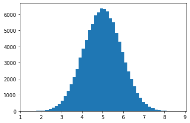

```python
n = 100000  # Sequence length
nu = 10     # number of uniforms in the sum

x = []
for i in range(n):
    x += [sum([np.random.rand() for i in range(nu)])]
p = plt.hist(x, bins=50)
```

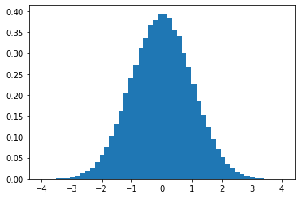

```python
x = np.array(x)
z = (x - np.mean(x))/np.std(x)
p = plt.hist(z, bins=50, density=True)
```

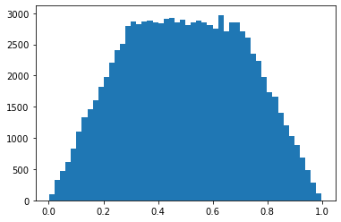

```python
n = 100000  # Sequence length
x = []
for i in range(n):
    x += [0.3*np.random.rand() + 0.7*np.random.rand()]
p = plt.hist(x, bins=50)
```

## A simple game

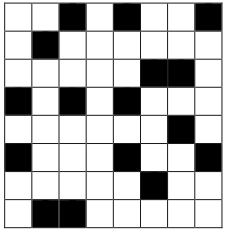

**Assigment 2**: Considering the board shown above, implement the following system: There are 2 mines distributed randomly in the black squares, and the player clicks randomly on the squares (never on the white ones): If there is no mine in the square, it becomes white, otherwise the player loses the game. If the player manages to click all the squares that do not have a mine, he/she win the game. Do not take into account the distribution (or proximity) of the black boxes.

```python
def minesweeper(black_squares):

    # Se generan los índices donde se ubicarán las minas
    first_mine = int(np.floor(np.random.rand() * black_squares))
    second_mine = int(np.floor(np.random.rand() * black_squares))

    # Si el índice coincide se repite la generación
    while first_mine == second_mine:
        # print('Se repitieron: ', first_mine, second_mine)
        second_mine = int(np.floor(np.random.rand() * black_squares))

    # Se genera el tablero en blanco
    board = np.zeros(black_squares, dtype=object)
    # print('Minas: ', first_mine, second_mine)

    # Se asignan los espacios en el tablero donde se colocarán las minas
    board[first_mine] = 1
    board[second_mine] = 1

    past_attempts = []

    game_finished = False
    attempt_number = 1

    while game_finished != True:

        # Se realiza el intento del jugador de forma aleatoria entre los recuadros negros
        attempt = int(np.floor(np.random.rand() * black_squares))

        # Si el jugador intenta dar clic en un recuadro negro
        if attempt not in past_attempts:

            # Si únicamente quedan 2 recuadros negros, el jugador gana
            if len(past_attempts) == black_squares - 2:
                game_finished = True
                return 1
            else:
                # Si en el recuadro negro se encuentra una mina, el jugador pierde
                if board[attempt] == 1:
                    # print(attempt)
                    # print('Perdiste en el intento #', attempt_number)
                    game_finished = True
                    return 0

            attempt_number += 1
            past_attempts.append(attempt)
            # print(past_attempts)
        # else:
            # print('Intento repetido: ', attempt)

black_squares = 8

print(random_clicks(black_squares))
```

[output not shown]

**Assignment 3**: What is the probability of winning the game?

```python
rep = 100000
games = []

for i in range(rep):
    games.append(minesweeper(16))

print('Probabilidad:', sum(games) / rep * 100, '%')
```

```
Probabilidad: 0.84 %
```

**Assigment 4**: How many clicks on average will a player make until they lose (include the click in which they find the mine)?

```python
def clicks_until_lose(black_squares):

    first_mine = int(np.floor(np.random.rand() * black_squares))
    second_mine = int(np.floor(np.random.rand() * black_squares))

    while first_mine == second_mine:
        # print('Se repitieron: ', first_mine, second_mine)
        second_mine = int(np.floor(np.random.rand() * black_squares))

    board = np.zeros(black_squares, dtype=object)
    # print('Minas: ', first_mine, second_mine)

    board[first_mine] = 1
    board[second_mine] = 1

    # print(board)

    past_attempts = []

    game_finished = False
    attempt_number = 1

    while game_finished != True:

        attempt = int(np.floor(np.random.rand() * black_squares))
        # print(attempt)

        if attempt not in past_attempts:

            # Si el jugador gana, no se contabiliza la cantidad de clicks
            if len(past_attempts) == black_squares - 2:
                # print('Número:', attempt)
                game_finished = True
                return 0
            else:

                # Si el jugador pierde se retorna la cantidad de clicks
                if board[attempt] == 1:
                    # print('Número:', attempt)
                    # print('Perdiste en el intento #', attempt_number)
                    game_finished = True
                    return attempt_number

            attempt_number += 1
            past_attempts.append(attempt)
            # print(past_attempts)
        # else:
            # print('Intento repetido: ', attempt)

black_squares = 8

rep = 100000
games = []

for i in range(rep):
    games.append(clicks_until_lose(16))

print('Clicks promedio hasta perder:', sum(games) / rep)
```

```
Clicks promedio hasta perder: 5.5415
```